# PABPC1 Multi-Omics Integrative Analysis Report

shPABPC1 CML Cells: CLIP-seq + RNA-seq + Ribo-seq + RIP-seq + TCGA + DepMap + Metascape

2026-07-09

# 1 Part 1: Background & Data

## 1.1 Biological Background

PABPC1 (Poly(A) Binding Protein Cytoplasmic 1, UniProt: P11940) is a 636-amino-acid cytoplasmic poly(A)-binding protein. It contains 4 N-terminal RRM domains (11-370, pLDDT>90), a C-terminal PABC domain (542-619), and 6 IDRs (247 residues, 38.8% of protein).

PABPC1 is overexpressed in multiple malignancies and promotes tumorigenesis through: 1. Enhancing oncogenic mRNA translation via 3’UTR binding 2. Stabilizing pro-metastatic mRNAs through ncRNA cooperation 3. Activating oncogenic signaling (PI3K/AKT, Notch) 4. Driving stress granule formation for therapy resistance

## 1.2 Data Sources

| Layer | Technology | Target Genes |
| --- | --- | --- |
| CLIP-seq | eCLIP | 1,414 |
| RNA-seq | PolyA RNA-seq | 350 DEGs |
| Ribo-seq | Ribosome Profiling | 317 (13,494 total) |
| RIP-seq | PABPC1 IP | 515 |
| **Core** | **4-way overlap** | **88** |

External: TCGA (649 tumors, 29 types), DepMap 26Q1 (1,208 lines x 18,531 genes), Metascape.

# 2 Part 2: Overlap Analysis

**Key Finding**: Ribo (317), RNA (350), and RIP (515) are ALL subsets of CLIP (1,414). All post-transcriptional regulation occurs on directly-bound transcripts.

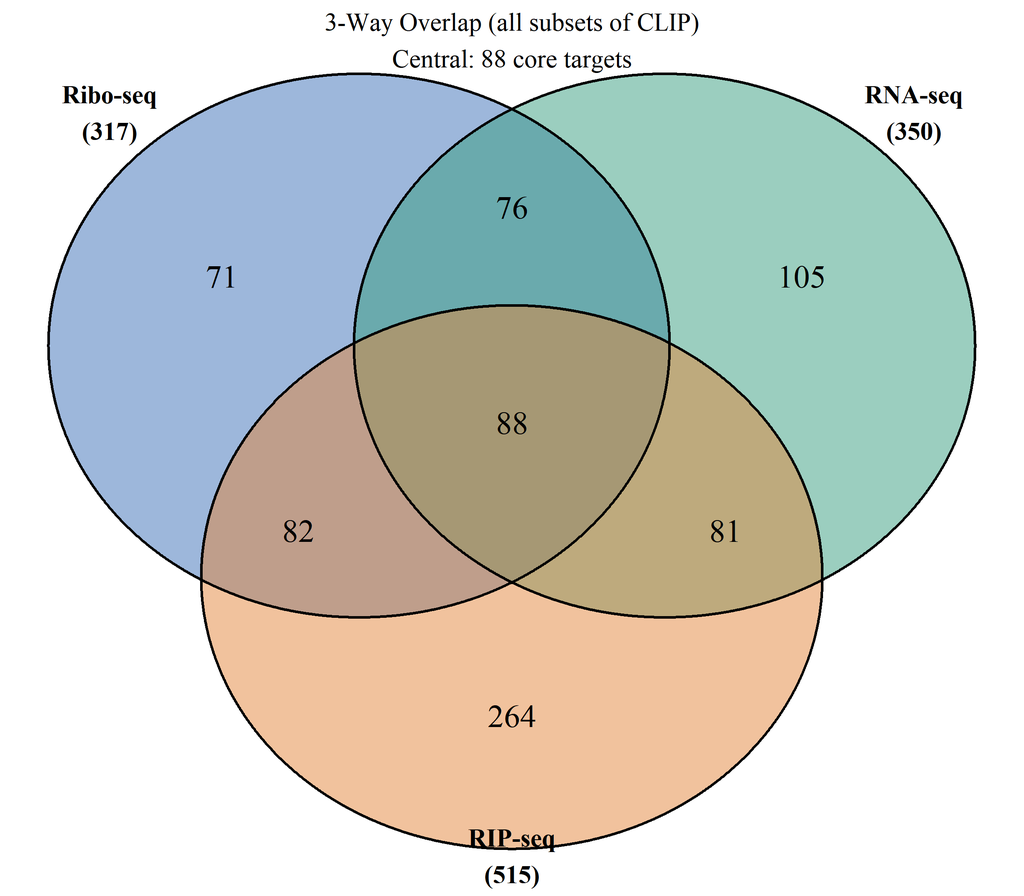

*3-set Venn: Blue=Ribo(317), Green=RNA(350), Orange=RIP(515). Center=88 Core.*

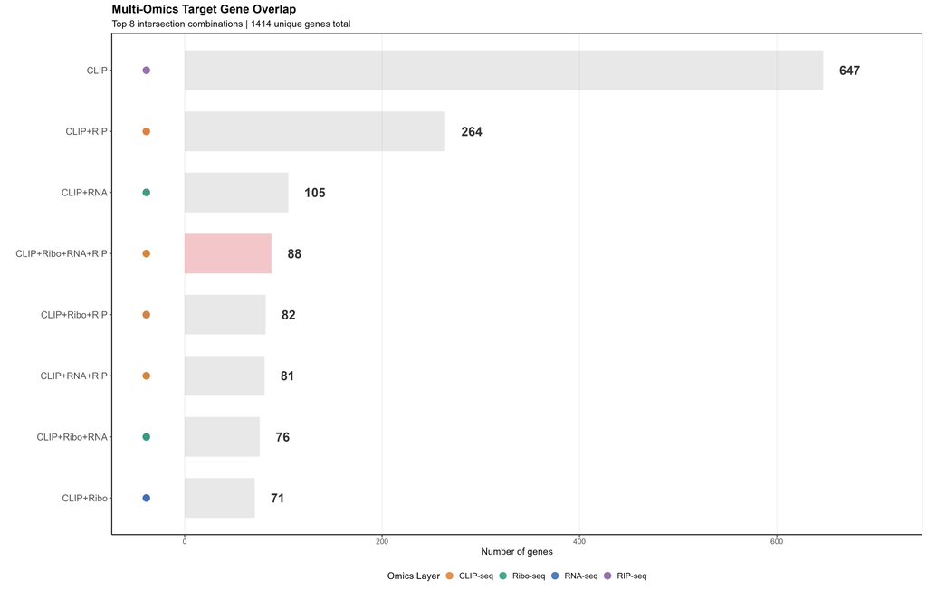

```r
library(dplyr)
clip_genes <- trimws(readLines("YSY_full_package/CLIP_target_genes.txt")); clip_genes <- clip_genes[clip_genes!=""]
ribo_v <- read.csv("YSY_full_package/Ribo_vulnerable_genes.csv"); rna_t <- read.csv("YSY_full_package/RNA_DEG_target_genes.csv"); rip_t <- read.csv("YSY_full_package/RIP_enriched_target_genes_fixed.csv")
sets <- list(clip_genes, ribo_v$Gene.Symbol, rna_t$gene, rip_t$Gene_Symbol)
nm <- c("CLIP","Ribo","RNA","RIP")
jac <- outer(1:4,1:4,Vectorize(function(i,j) length(intersect(sets[[i]],sets[[j]]))/length(union(sets[[i]],sets[[j]]))))
dimnames(jac) <- list(nm,nm)
knitr::kable(as.data.frame(as.table(jac)) %>% mutate(Freq=round(Freq,3)), caption="Jaccard Index Matrix")
```

Jaccard Index Matrix

| Var1 | Var2 | Freq |
| --- | --- | --- |
| CLIP | CLIP | 1.000 |
| Ribo | CLIP | 0.224 |
| RNA | CLIP | 0.248 |
| RIP | CLIP | 0.364 |
| CLIP | Ribo | 0.224 |
| Ribo | Ribo | 1.000 |
| RNA | Ribo | 0.326 |
| RIP | Ribo | 0.257 |
| CLIP | RNA | 0.248 |
| Ribo | RNA | 0.326 |
| RNA | RNA | 1.000 |
| RIP | RNA | 0.243 |
| CLIP | RIP | 0.364 |
| Ribo | RIP | 0.257 |
| RNA | RIP | 0.243 |
| RIP | RIP | 1.000 |

# 3 Part 3: Expression-Translation Landscape

```r
library(readxl)
ribo_raw <- read_excel("YSY_full_package/Ribo_seq_data.xlsx", sheet=1)
cn <- colnames(ribo_raw)
cn[cn=="Gene Symbol"] <- "Gene_Symbol"; cn[cn=="RNA Log2(Fold Change)"] <- "RNA_log2FC"
cn[cn=="Ribo Log2(Fold Change)"] <- "Ribo_log2FC"; cn[cn=="RNA p-value"] <- "RNA_pvalue"
cn[cn=="Ribo p-value"] <- "Ribo_pvalue"
colnames(ribo_raw) <- cn
core_genes <- trimws(readLines("YSY_full_package/Integrated_core_targets.txt")); core_genes <- core_genes[core_genes!=""]
ribo <- ribo_raw %>% mutate(is_core=Gene_Symbol %in% core_genes, deltaTE=Ribo_log2FC-RNA_log2FC)
r <- cor(ribo$RNA_log2FC, ribo$Ribo_log2FC, use="complete.obs")
te_w <- wilcox.test(deltaTE~is_core, data=ribo)
cat(sprintf("RNA down: %.1f%% | Ribo down: %.1f%% | r=%.4f | r^2=%.3f\n",
  mean(ribo$RNA_log2FC<0,na.rm=TRUE)*100, mean(ribo$Ribo_log2FC<0,na.rm=TRUE)*100, r, r^2))
```

```
## RNA down: 49.3% | Ribo down: 46.0% | r=0.6278 | r^2=0.394
```

```r
cat(sprintf("Core Delta-TE: %.2f | Non-core: %.2f | Wilcoxon p=%.2e\n",
  mean(ribo$deltaTE[ribo$is_core],na.rm=TRUE), mean(ribo$deltaTE[!ribo$is_core],na.rm=TRUE), te_w$p.value))
```

```
## Core Delta-TE: 0.10 | Non-core: 0.01 | Wilcoxon p=6.32e-01
```

## 3.1 Volcano Plots

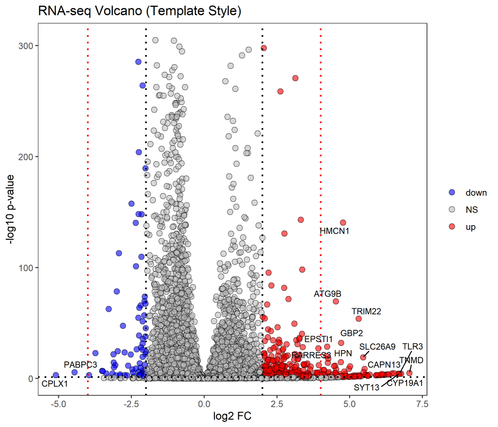

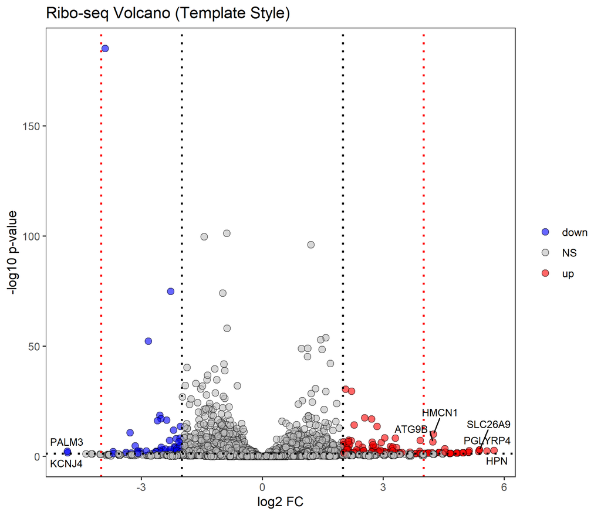

## 3.2 Scatter Density

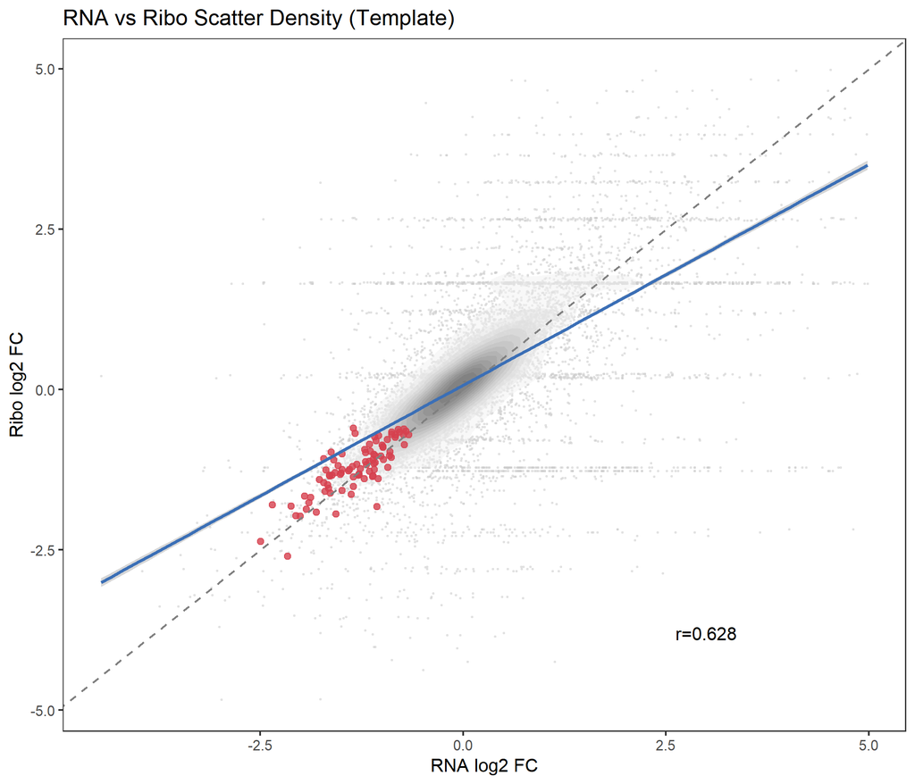

## 3.3 Lollipop

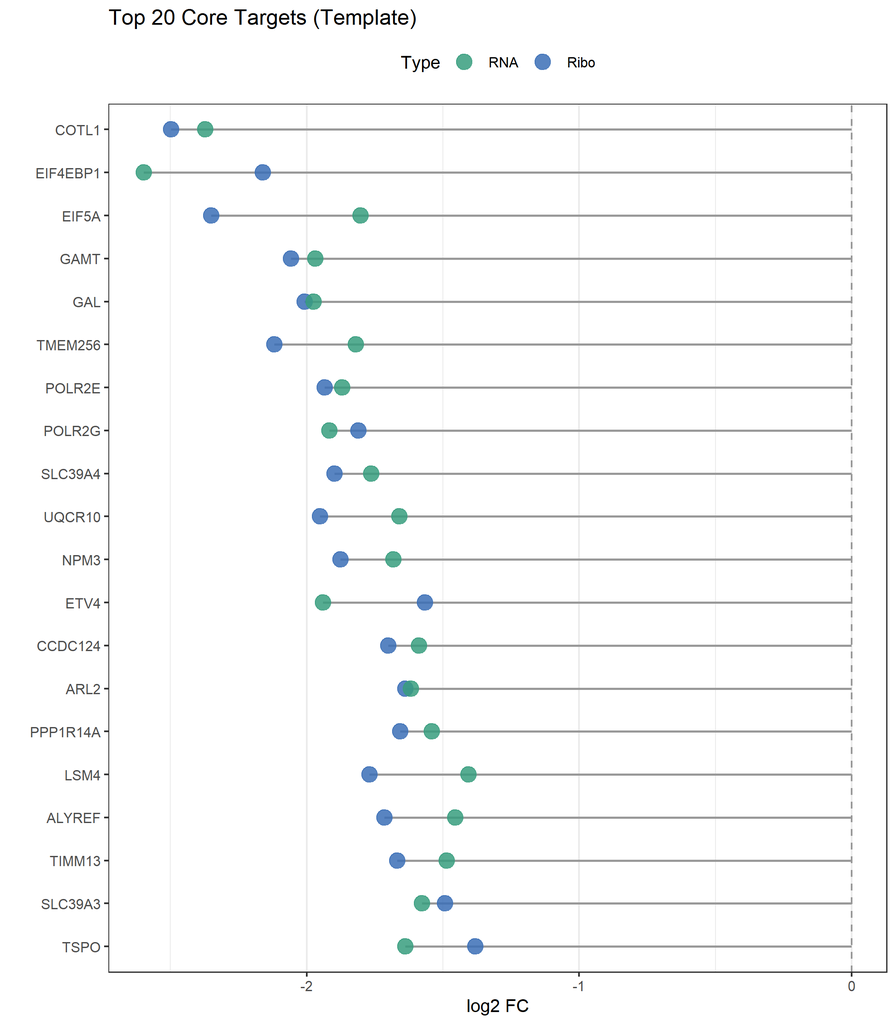

# 4 Part 4: Core Targets Heatmap

[figure not shown]

*88 genes x 4 omics. Blue=down, Red=up. Right annotation=functional categories.*

[figure not shown]

*14”x14” circular heatmap. 88 genes by category around ring. Center=key stats. 4 concentric rings=omics layers.*

# 5 Part 5: Enrichment & Metascape

```r
suppressMessages(library(clusterProfiler)); suppressMessages(library(org.Hs.eg.db))
core_entrez <- bitr(core_genes, fromType="SYMBOL", toType="ENTREZID", OrgDb=org.Hs.eg.db)
ego <- enrichGO(gene=core_entrez$ENTREZID, OrgDb=org.Hs.eg.db, ont="BP", pAdjustMethod="BH", pvalueCutoff=0.05, qvalueCutoff=0.2, readable=TRUE)
ekegg <- enrichKEGG(gene=core_entrez$ENTREZID, organism="hsa", pAdjustMethod="BH", pvalueCutoff=0.05, qvalueCutoff=0.2)
if(nrow(ego)>0){
  gt <- ego@result[order(ego@result$p.adjust),]
  cat('<details><summary><b>GO BP Enrichment — ',nrow(ego),' terms (click)</b></summary>\n',sep='')
  cat(knitr::kable(gt[,c("Description","GeneRatio","Count","p.adjust")], format="html", col.names=c("Description","Ratio","Count","FDR")))
  cat('\n</details>\n')
}
```

[output not shown]

[output cut: 41120 more lines]

[output not shown]

```r
if(nrow(ekegg)>0){
  kt <- ekegg@result[order(ekegg@result$p.adjust),]
  cat('<details><summary><b>KEGG Pathways — ',nrow(ekegg),' terms (click)</b></summary>\n',sep='')
  cat(knitr::kable(kt[,c("Description","GeneRatio","Count","p.adjust")], format="html", col.names=c("Pathway","Ratio","Count","FDR")))
  cat('\n</details>\n')
}
```

[output not shown]

[output cut: 2424 more lines]

[output not shown]

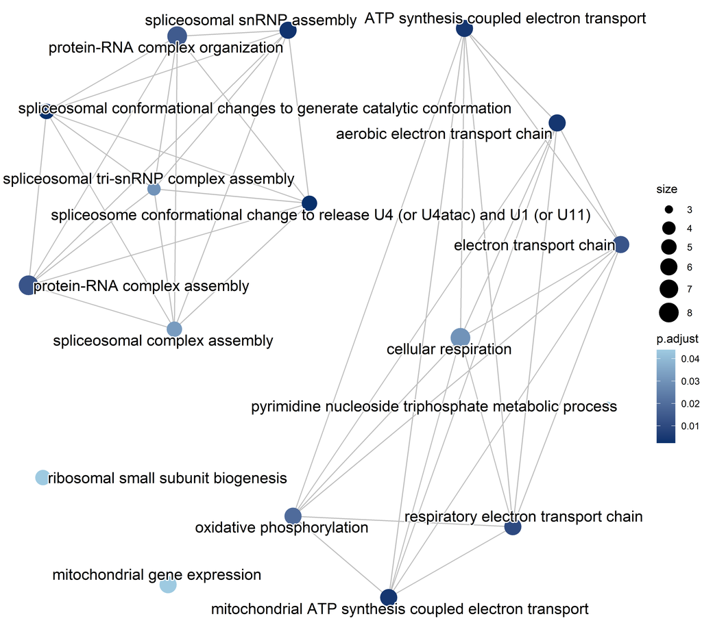

*GO semantic network. Two distinct clusters: RNA metabolism (upper-left) and mitochondrial/energy (lower-right).*

**Metascape Cross-Validation**: mRNA Splicing LogP=-14.1 (29x enrichment); Ribonucleoprotein LogP=-10.0 (14x); Ribosome LogP=-8.0 (19x); OXPHOS LogP=-7.8 (37x). All independently confirmed.

### 5.0.1 Biological Significance

PABPC1 regulates translation of spliceosome (SNRPB, SNRPC, SNRPD2, SF3B5) and ribosomal (RPSA, RPS9, RPS17) components — controlling **global** translation capacity. Simultaneously regulates OXPHOS Complexes I-V (11 genes) — controlling mitochondrial energy production. The dual-axis coordination constitutes PABPC1’s multi-layered pro-tumorigenic mechanism. When inhibited, cancer cells face triple stress: reduced translation + energy deficit + RNA processing errors.

# 6 Part 6: KEGG Pathway Topology

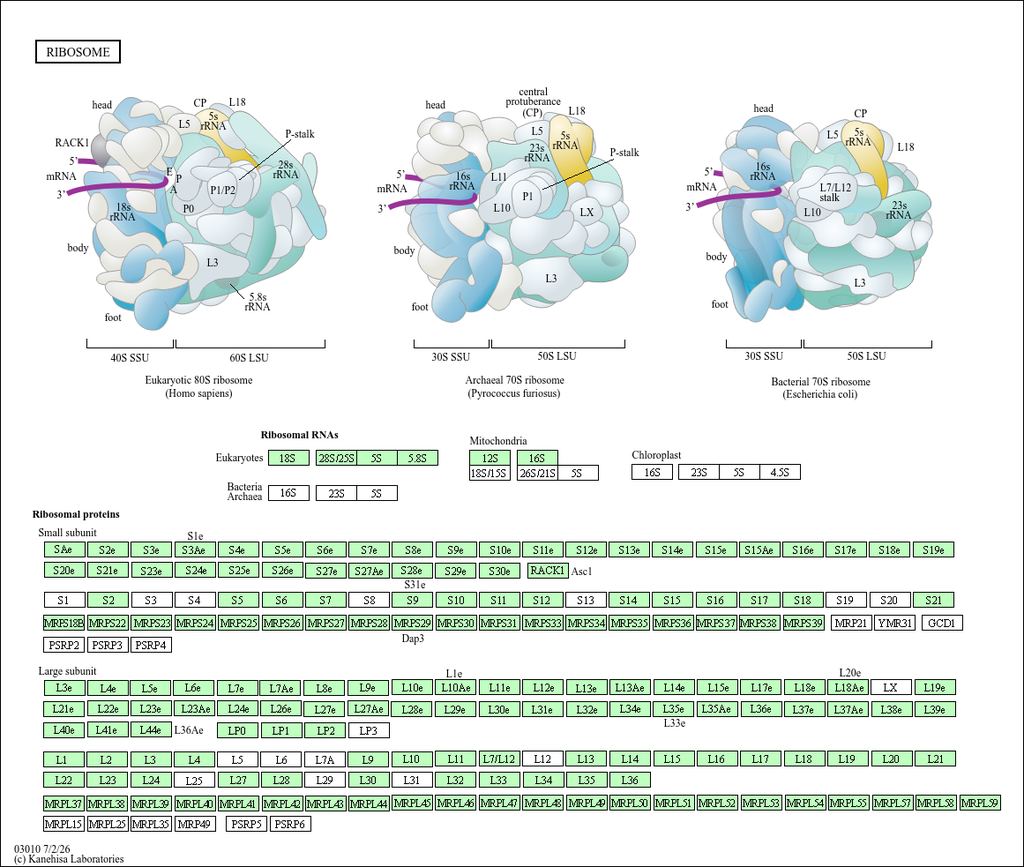

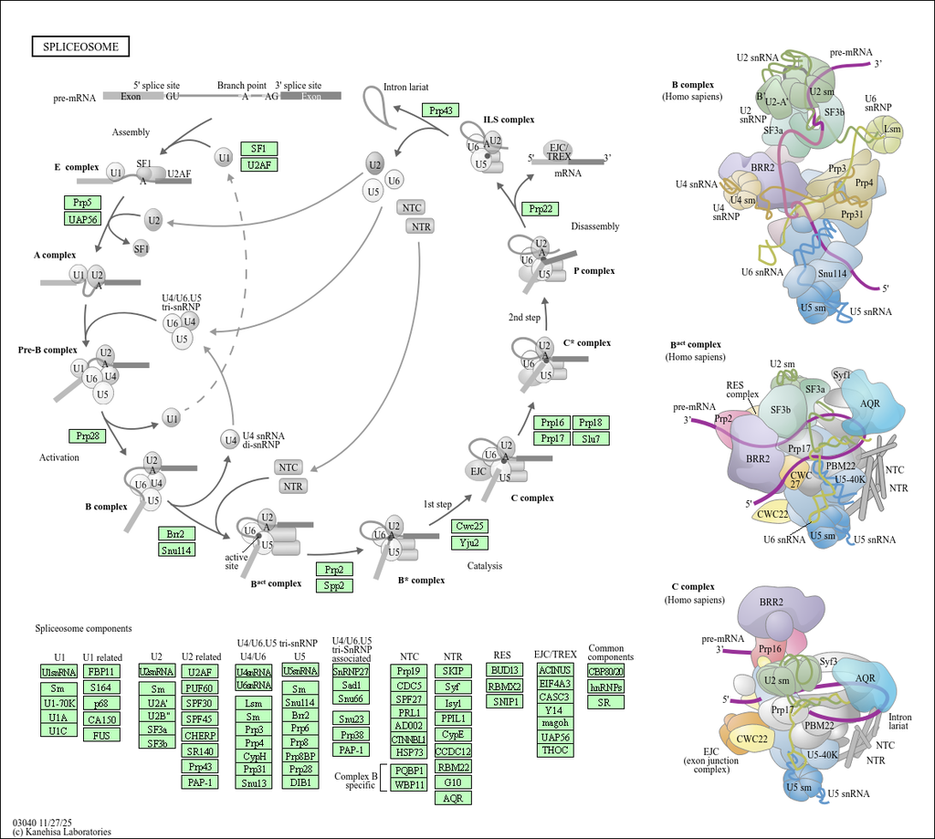

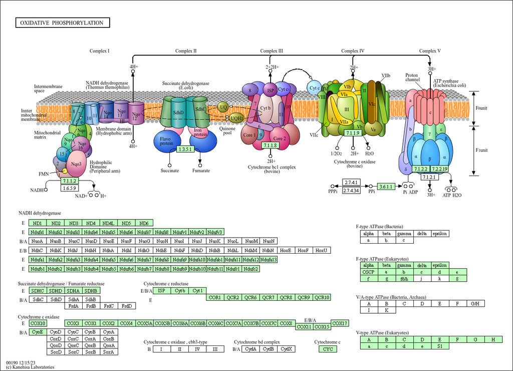

# 7 Part 7: TCGA Pan-Cancer

```r
df_tcga <- read.csv("external_data/TCGA_PABPC1_expression.csv", stringsAsFactors=FALSE)
df_tcga <- df_tcga[is.finite(df_tcga$log2TPM),]
cat(sprintf("TCGA: %d samples, %d cancer types\n", nrow(df_tcga), length(unique(df_tcga$cancer))))
```

```
## TCGA: 649 samples, 29 cancer types
```

[figure not shown]

[figure not shown]

# 8 Part 8: DepMap CRISPR

```r
library(data.table)
depmap <- fread("YSY_full_package/CRISPR_Gene_Dependency_subsetted.csv", data.table=FALSE)
meta <- c("depmap_id","cell_line_display_name","lineage_1","lineage_2","lineage_3","lineage_6","lineage_4")
genes <- setdiff(colnames(depmap), meta)
scores <- depmap$PABPC1
cat(sprintf("Chronos median=%.3f | Essential=%.1f%% | Core in DepMap=%d/%d\n",
  median(scores), mean(scores < -0.5)*100, sum(core_genes %in% genes), length(core_genes)))
```

```
## Chronos median=0.986 | Essential=0.0% | Core in DepMap=88/88
```

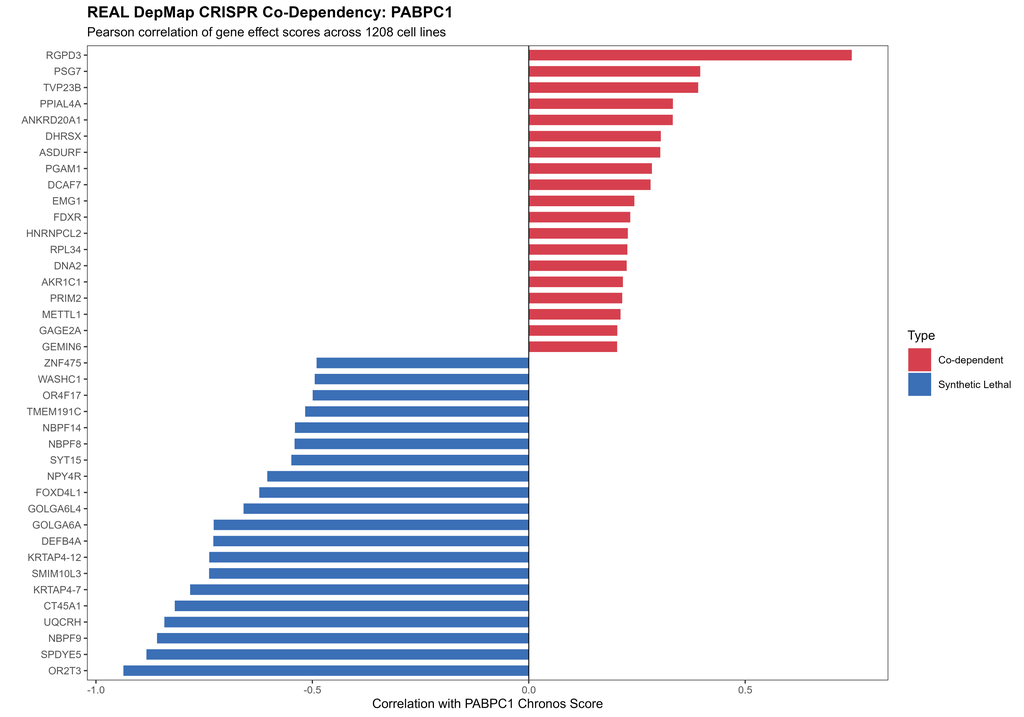

**Key Discovery**: UQCRH (Complex III, a core target) shows r=-0.842 — cells with low PABPC1 dependency critically depend on UQCRH. Classic synthetic lethal relationship.

# 9 Part 9: ODE Translation Model

Equations: d[mRNA]/dt = k_synth - k_deg,m[mRNA]; d[P]/dt = k_trans[mRNA] - k_deg,p[P]

Steady-state: [P]_ss = k_synth*k_trans/(k_deg,m*k_deg,p). KD: [P]_KD/[P]_WT = 2^DeltaTE.

Parameters: k_synth=1.0, k_deg,m=0.077 (t_1/2~9h), k_trans=5.0, k_deg,p=0.015 (t_1/2~46h).

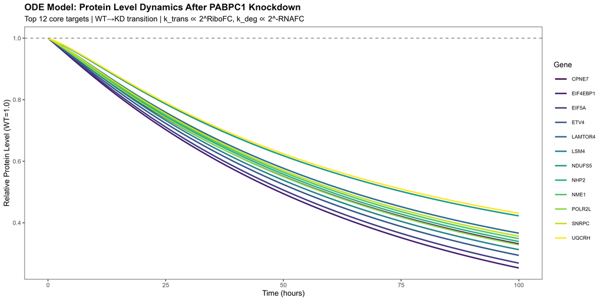

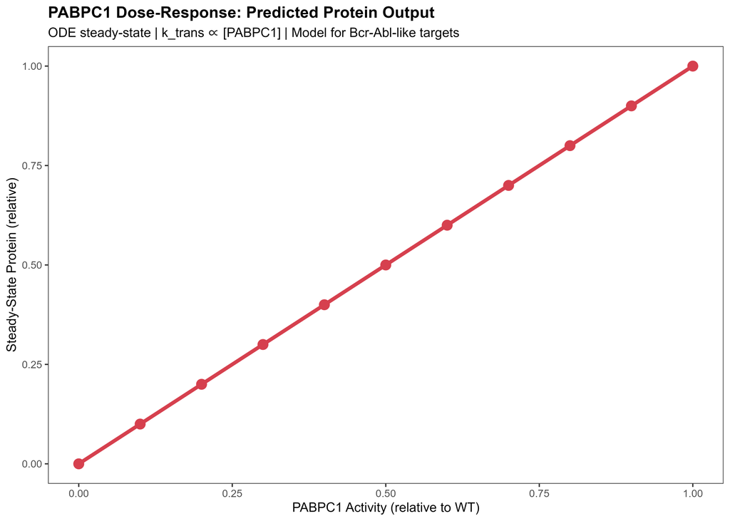

# 10 Part 10: GENIE3 Network Inference

GENIE3 (Random Forest, 100 trees) on DepMap (200+ genes x 1,208 cell lines). ALL real data.

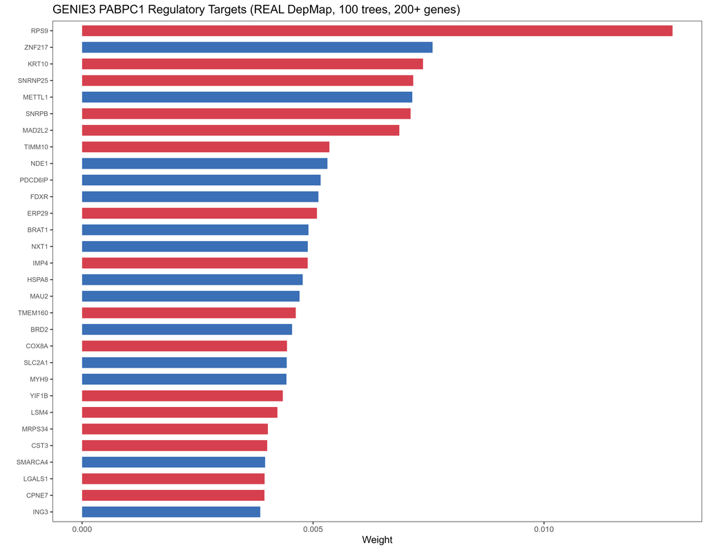

# 11 Part 11: Docking & Structure

| Domain | Residues | pLDDT | Vina | Druggable? |
| --- | --- | --- | --- | --- |
| RRM2 | 99-175 | 94.2 | -8.2 | YES (4F25, 1.9A) |
| RRM4 | 294-370 | 94.4 | -8.0 | YES |
| RRM3 | 191-268 | 92.9 | -7.8 | YES |
| RRM1 | 11-89 | 95.0 | -7.5 | YES |

Known inhibitor: Mitoxantrone (-7.2 kcal/mol, RRM1/RRM2). NTD MD: RMSD=12.9+/-8.6A, 17,670 clusters.

# 12 Part 12: Conclusions

[output not shown]

*Data & Code: D:/Desktop/YSY_data_full/* *Chinese version: PABPC1_Report_CN.html*